# Civil Rights

POLS 2311: Government of the United States

## Agenda

- Define *civil rights* and *discrimination*
- Understand *equal protection* under the *Fourteenth Amendment*
- Know a brief history of how civil rights have developed in the US

## Civil Liberties and Civil Rights

- **Civil liberties**: *limitations on government power, intended to protect freedoms upon which governments may not legally intrude*
- **Civil rights**: *guarantees that government officials will treat people equally and that decisions will be made on the basis of merit rather than race, gender, or other personal characteristics*

## Discrimination

- How would you define discrimination?
- **Discrimination**: *the unjust or prejudicial treatment of different categories of people, especially on the grounds of race, age, or sex*
- *Discriminatory effect* (or discriminatory impact) a law results in different treatment for similar individuals.
- *Discriminatory purpose* a law was enacted with the intent to unjustly or prejudicially treat certain people differently

## Two Views of Equality

### Equality of Results

- Focuses on *outcomes*: a diverse workforce, test results, admissions
- Critics: does this address underlying causes, or just their statistical symptom?

### Equality of Opportunity

- Focuses on making a process available to all, *race-neutral*
- Critics: implicit bias; can any process be truly “colorblind”?

# Slavery

## Slavery and the Constitution

- The 3/5’s compromise
- Prohibited the abolition of the foreign slave trade until 1808
  - *The Act Prohibiting Importation of Slaves* of 1807
- Permitted the domestic slave trade
- Required states, including states that did not permit slavery, to return freedom seekers who came there for refuge

## The Missouri Compromise 1820

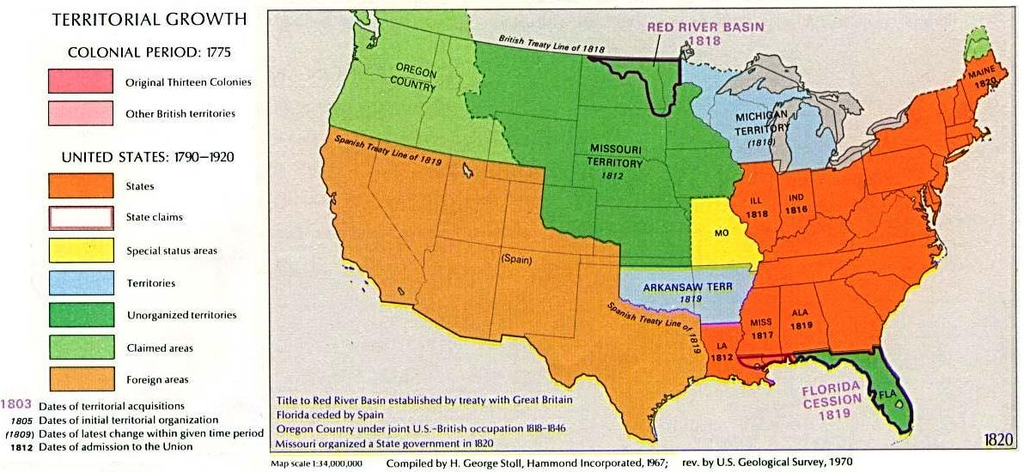

## Frederick Douglass

*What, to the American slave, is your 4th of July? I answer; a day that reveals to him, more than all other days in the year, the gross injustice and cruelty to which he is the constant victim. . . . The existence of slavery in this country brands your republicanism as a sham, your humanity as a base pretense, and your Christianity as a lie*

-1852 Independence Day address to the Rochester Ladies’ Anti-Slavery Society

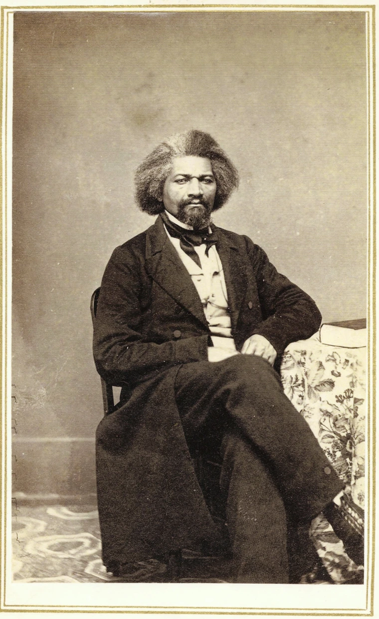

## Dred Scott

*Dred Scott v. Sandford* (1857)

- *The question is simply this: Can a negro, whose ancestors were imported into this country, and sold as slaves, become a member of the political community formed and brought into existence by the Constitution of the United States, and as such become entitled to all of the rights, and privileges, and immunities, guarantied [sic] by that instrument to the citizen?*

[figure not shown]

## The Civil War

*[T]he State of South Carolina having resumed her separate and equal place among nations, deems it due to herself, to the remaining United States of America, and to the nations of the world, that she should declare the immediate causes which have led to this act…*

**[A]n increasing hostility on the part of the non-slaveholding States to the institution of slavery**, has led to a disregard of their obligations, and the laws of the General Government have ceased to effect the objects of the Constitution.

-South Carolina Declaration of Secession (1860)

[figure not shown]

## Reconstruction (1865-1877)

- State governments were reorganized before the rebellious states were allowed to be readmitted to the Union
- Reconstruction Amendments
  - Thirteenth Amendment (1865)
  - Fourteenth Amendment (1868)
  - Fifteenth Amendment (1870): *Can’t deny the vote to men based on “race, color, or previous condition of servitude”*

## Thirteenth Amendment

*Neither slavery nor involuntary servitude, except as a punishment for crime whereof the party shall have been duly convicted, shall exist within the United States, or any place subject to their jurisdiction*

## Fourteenth Amendment

*All persons born or naturalized in the United States, and subject to the jurisdiction thereof, are citizens of the United States and of the State wherein they reside. No State shall make or enforce any law which shall abridge the privileges or immunities of citizens of the United States; nor shall any State deprive any person of life, liberty, or property, without **due process** of law; nor deny to any person within its jurisdiction the **equal protection** of the laws*

## Fourteenth Amendment

- **Due Process Clause**: civil liberties
- **Equal Protection Clause**: *No State shall . . . deny to any person within its jurisdiction the equal protection of the laws*
  - involves principles of equality, fairness, and freedom from discrimination; but limited

## Equal Protection in the Courts

- Does the law have a discriminatory intent?
- Discriminatory purpose evaluated on different levels of *scrutiny*
- **Protected classes**
  - race, religion, national origin
  - receive the highest level of scrutiny

## Tiers of Scrutiny

| Tier | Classifications | Standard | Example |
| --- | --- | --- | --- |
| **Strict** | Race, national origin, religion | Narrowly tailored to a *compelling* interest | Barring marriage/adoption based on race |
| **Intermediate** | Sex/gender | Substantially related to an *important* interest | Sex-differentiated hospital delivery-room policies |
| **Rational basis** | Everything else | Rationally related to a *legitimate* interest | Federal minimum drinking-age law |

# The End of Reconstruction

## The Compromise of 1877

- The 1876 presidential election
  - Rutherford B. Hayes (Rep) v. Samuel J. Tilden (Dem)
  - Tilden won popular vote, yet Hayes won the electoral college
- In exchange for the removal of US troops from the southern states where they remained (Louisiana, South Carolina, and Florida), Hayes was given the electoral college votes of those states
- The beginning of the *Jim Crow Era*

## The Jim Crow Era

### Disenfranchisement

- Literacy tests
- Understanding tests
- White primary
- Poll tax

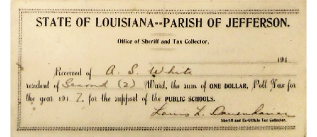

## The Jim Crow Era

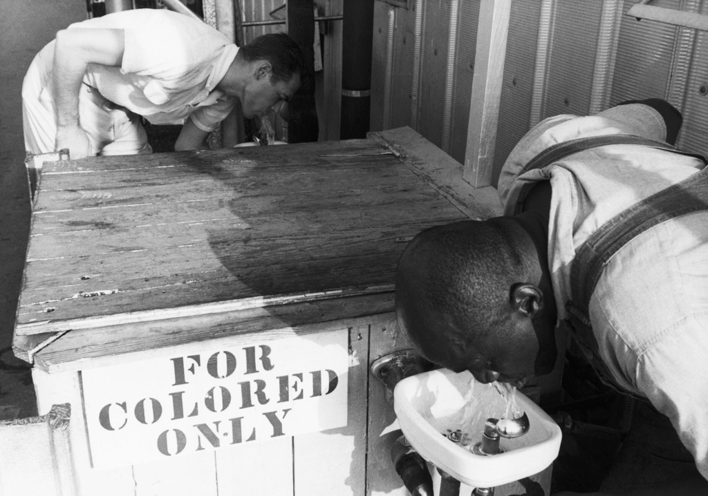

## The Jim Crow Era

### Segregation

- *De facto*: results from the private choices of individuals
- *De jure*: results from government discrimination or laws that foster segregation
  - *Plessy v. Ferguson* (1896): “Separate but equal”

# The Fight for Civil Rights

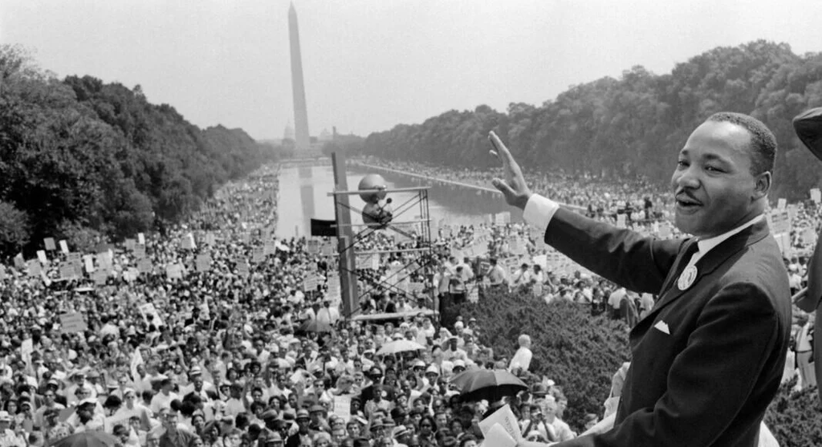

## Civil Disobedience

- The most famous examples of segregation – segregated schools, separate accommodations on public transit, and the exclusion of persons of color from commercial establishments – were the first areas targeted by civil disobedience and direct action campaigns during the Civil Rights Movement
- Civil rights campaigners often faced tough–and sometimes violent–local and law enforcement opposition

## Civil Disobedience

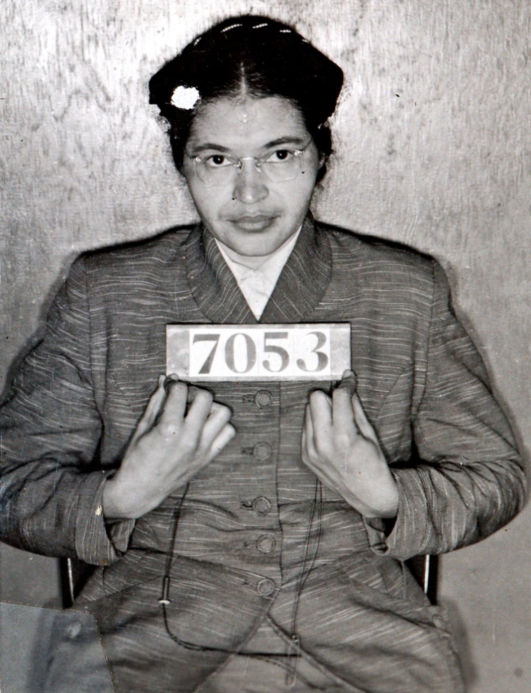

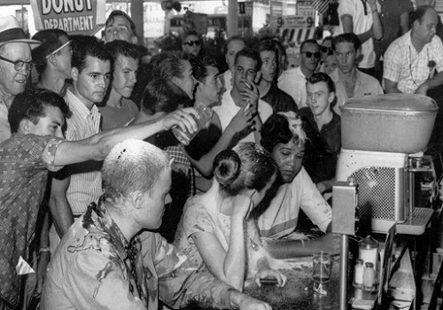

## Civil Disobedience

[figure not shown]

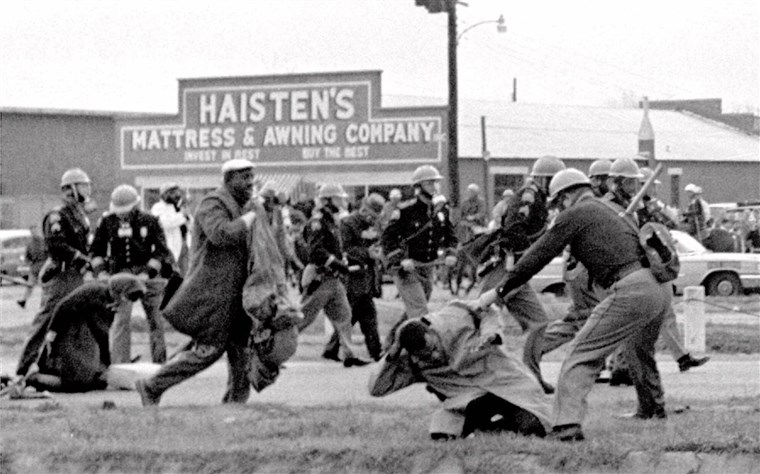

## Chipping Away at *Plessy*

- *McLaurin v. Oklahoma State Regents* and *Sweatt v. Painter* showed that truly equal “separate but equal” facilities were difficult to maintain in practice
- Paved the way for a direct challenge to *Plessy* itself

## Brown v. Board of Education (1954)

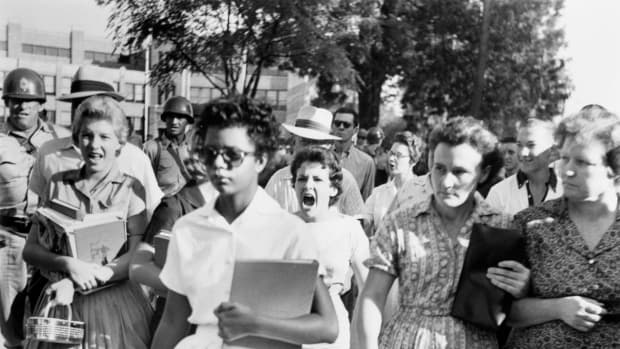

## Desegregation vs. Integration

- *Brown* made *de jure* segregation illegal — but *de facto* segregation (arising from residential patterns and private choices) remained unresolved
- Some districts turned to busing as a remedy
  - *Swann v. Charlotte-Mecklenburg Board of Education* (1971): upheld busing despite intense protest
- *Analyzing data from U.S. public schools going back to 1967, the researchers found that segregation between white and Black students has increased by 64 percent since 1988 in the 100 largest districts, and segregation by economic status has increased by about 50 percent since 1991*

## The Civil Rights Act of 1964

- Outlawed government discrimination and the unequal application of voting qualifications by race
- Outlawed segregation and other forms of discrimination by most businesses that were open to the public, including hotels, theaters, and restaurants that were not private clubs
  - Commerce Clause
- Prohibited discrimination on the basis of race, ethnicity, religion, sex, or national origin by most employers
  - *Equal Employment Opportunity Commission* (EEOC)

## The Voting Rights Act of 1965

- Prohibited disenfranchisement of racial and ethnic minorities; banned literacy tests nationwide
- **Preclearance** (Section 5): covered states/localities needed federal approval before changing voting laws
- **Section 2**: bars voting practices — including district maps — that give minority voters less opportunity to elect candidates of their choice
- *Shelby County v. Holder* (2013, 5-4): struck down the preclearance **coverage formula** as based on outdated data
  - Preclearance is now dormant; Congress has not enacted a replacement

## Section 2 and Vote Dilution

- After *Shelby County*, Section 2 is the VRA’s main enforcement tool — and it applies nationwide
- *Thornburg v. Gingles* (1986): a minority group can challenge a map when it is (1) large and compact enough to form its own district, (2) politically cohesive, and (3) usually outvoted by a white bloc
- *Allen v. Milligan* (2023, 5-4): surprised observers by **upholding** Section 2, ordering Alabama to draw a second majority-Black district

## *Louisiana v. Callais* (2026)

- Just three years after *Milligan*, the Court (opinion by Alito) reworked the *Gingles* framework
- Plaintiffs must now **“control for party”** — show that race, not partisanship, explains the voting split
- A plaintiff’s proposed map must also satisfy the **state’s own partisan goals** (protecting incumbents, hitting a target seat count)
- **Kagan, dissenting**: where a state draws every seat for one party, “any map with a majority-Black district will not be a map with all Republican seats” — so a violation becomes impossible

## The Voting Rights Act in 2025–2026

- Both of the VRA’s core tools have been narrowed by the **Court**, not repealed by Congress
  - Preclearance — *Shelby County* (2013); Section 2 vote dilution — *Callais* (2026)
- *Alexander v. South Carolina State Conference of the NAACP* (2023): a state’s claim of **partisan** intent defeats a racial-gerrymandering challenge
- Some read *Callais* as edging toward **“race-indifference”** — where drawing a district even *to comply with the VRA* is constitutionally suspect
- **Shadow docket** (2026): the Court let Louisiana redraw its map mid-election, dropping a majority-Black district, for the 2026 midterms

## Rights for Women

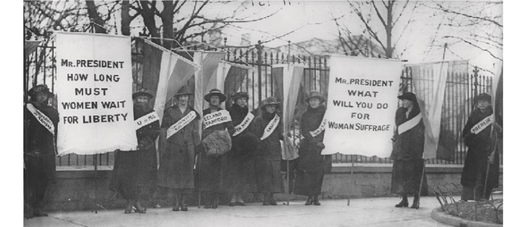

## Rights for Women

### Seneca Falls (1848)

- **The Declaration of Sentiments and Resolutions**
  - *we hold these truths to be self-evident: that all men **and women** are created equal*

[figure not shown]

## Rights for Women

- Right to vote
  - Nineteenth Amendment (1920)
- The *women’s rights movement* began in the 1960
  - medical privacy and autonomy, keep surname, own property, obtain credit, attend schools, equal pay
  - The Equal Rights Amendment (ERA)
  - The Education Amendments of 1972
    - **Title IX**: applies to all educational institutions that receive federal aid and prohibits discrimination on the basis of sex in academic programs, dormitory space, health-care access, and school activities including sports
  - The *Lilly Ledbetter Fair Pay Act* (2009)

## Privacy and Reproductive Rights

- States historically regulated sexual matters under their *reserved powers*
- *Roe v. Wade* (1973): asserted a fundamental right to abortion under the right to privacy
- *Planned Parenthood v. Casey* (1992)
  - Undue burdens
- *Dobbs v. Jackson Women’s Health Organization* (2022): held the Constitution does not confer a right to abortion, returning regulation to the states

## Native Americans

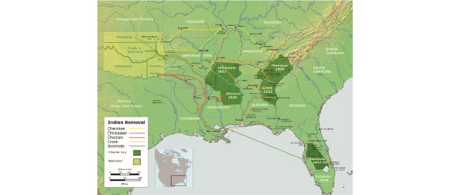

## Native Americans

- **The Indian Removal Act** (1830)
  - Native Americans were forcibly removed from the eastern United States along the *Trail of Tears* from 1831-1838
- **Indian Citizenship Act** (1924)
  - Granted citizenship
- **The Indian Civil Rights Act** (1968)
  - Extended civil rights and liberties to reservations

## LGBTQ+ Rights

- Stonewall Inn (1969)
- *Bowers v. Hardwick* (1986): upheld state sodomy laws
- *Defense of Marriage Act* of 1996
  - Federal government left recognition of same-sex marriage to the states
- *Lawrence v Texas* (2003): overturned *Bowers*, struck down sodomy laws
- *Obergefell v. Hodges* (2015): nationwide constitutional right to same-sex marriage

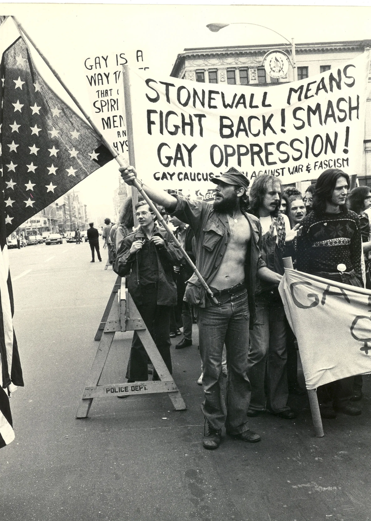

## Immigrants

### Fourteenth Amendment

*All persons **born or naturalized** in the United States, and subject to the jurisdiction thereof, are citizens of the United States and of the State wherein they reside. No State shall make or enforce any law which shall abridge the privileges or immunities of citizens of the United States; nor shall any State deprive **any person** of life, liberty, or property, without due process of law; nor deny to any person within its jurisdiction the equal protection of the laws*

## Immigrants

- **Birthright citizenship**: Anyone born in the U.S. is a citizen, regardless of parents’ immigration status
  - *United States v. Wong Kim Ark* (1898)
- Equal protection applies to *all persons*
  - *Yick Wo v. Hopkins* (1886)
- Due process applies to *all persons*
  - *Wong Wing v. United States* (1896)

## Executive Order 14160 (2025)

- Jan. 20, 2025: sought to deny birthright citizenship to children born in the U.S. when
  - both parents were unlawfully present, **or**
  - one parent was unlawfully present and the other only lawfully but temporarily present
- Blocked by federal courts; never took effect
- *Trump v. CASA* (2025, 6-3): nationwide injunctions exceed district courts’ authority — merits left unresolved

## *Trump v. Barbara* (2026)

- Supreme Court struck down EO 14160 on the merits (5-4 constitutional; 6-3 unlawful)
- **Majority (Roberts)**: “subject to the jurisdiction thereof” means “under its dominion” — covers children of parents present lawfully *or* unlawfully
  - Traces the rule through English common law, the 14th Amendment’s 1868 ratification, and *Wong Kim Ark* (1898)
  - The 14th Amendment enshrines “the right to have rights”
- **Dissent (Thomas, joined by Gorsuch)**: birthright citizenship also requires **domicile** — those unlawfully or temporarily present remain domiciled abroad
- **Concurrence (Kavanaugh)**: EO invalid, but on *statutory*, not constitutional, grounds — leaves a legislative path open

## Two Views of Equality

### Equality of Results

- Focuses on *outcomes*: a diverse workforce, test results, admissions
- Critics: does this address underlying causes, or just their statistical symptom?

### Equality of Opportunity

- Focuses on making a process available to all, *race-neutral*
- Critics: implicit bias; can any process be truly “colorblind”?